# Exploring the BRFSS data

We select the categories “White” and “Black or African American” to analyze the differences. Those are the two population with the highest number of observations, which strengthens the robustness of the analysis.

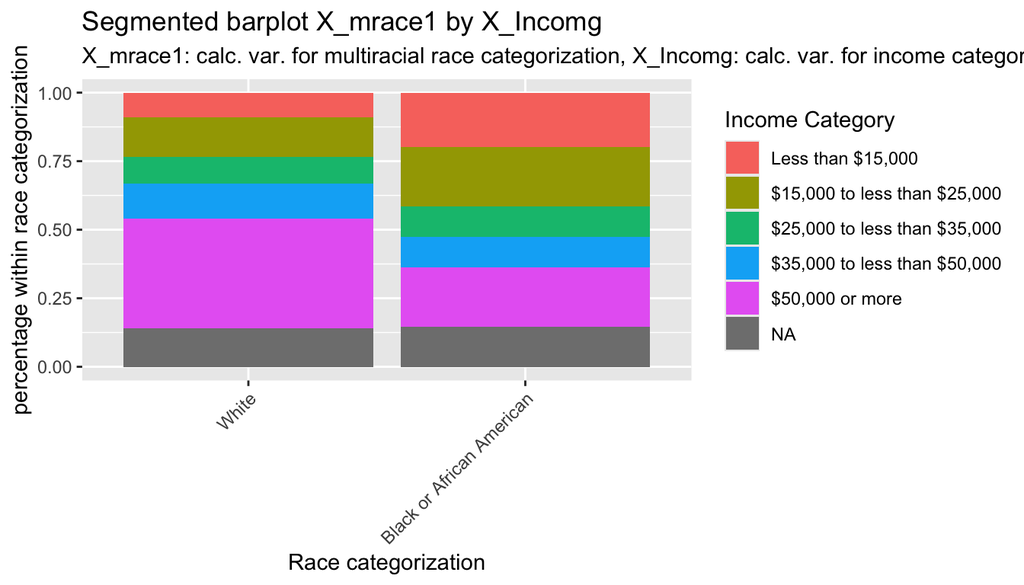

```r
brfss2013_clean %>%
  filter(X_mrace1 == "White" | X_mrace1 =="Black or African American")%>%
  ggplot(aes(x=X_mrace1, fill=X_incomg)) +
  geom_bar(position="fill") +
  labs(x="Race categorization", y="percentage within race categorization", fill= "Income Category", title = "Segmented barplot X_mrace1 by X_Incomg", subtitle= "X_mrace1: calc. var. for multiracial race categorization, X_Incomg: calc. var. for income category")+
  theme(axis.text.x = element_text(angle=45, hjust=1))
```

The distribution of the income is different depending on the race categorization “White” or “Black or African American”. The category “Black or African American” have Income category “Less than $15,000” and “$15,000 to less than $25,000” higher than in the category “White”. On the contrary, The proportion of the Income categories “$35,000 to less than $50,000” and “$50,000 or more” are higher in the category “White”, than in the category “Black or African American”.

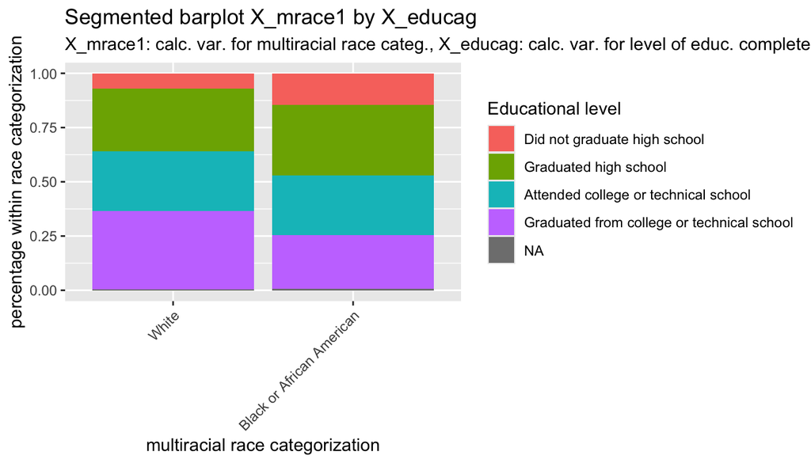

```r
brfss2013_clean %>%
  filter(X_mrace1 == "White" | X_mrace1 =="Black or African American")%>%
  ggplot(aes(x=X_mrace1, fill=X_educag)) +
  geom_bar(position="fill") +
  labs(x="multiracial race categorization", y="percentage within race categorization", fill= "Educational level", title = "Segmented barplot X_mrace1 by X_educag", subtitle= "X_mrace1: calc. var. for multiracial race categ., X_educag: calc. var. for level of educ. completed")+
  theme(axis.text.x = element_text(angle=45, hjust=1))
```

The category “Black or African American” have a higher proportion in the category “Did not graduate high school” than the category “white”. On the contrary, The proportion of the Educational level category “Graduated from college or technical school” is higher in the category “White”, than in the category “Black or African American”.

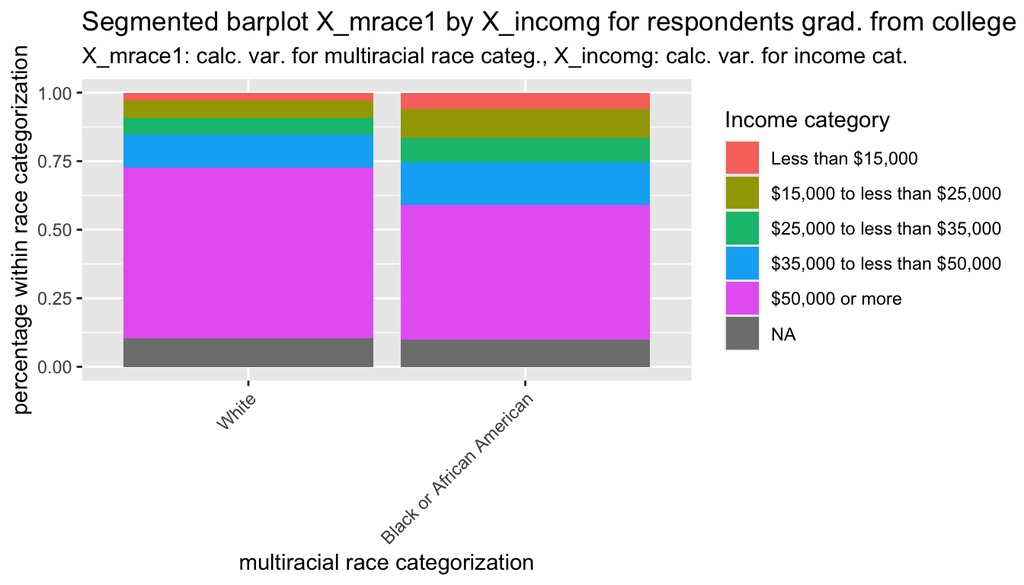

```r
brfss2013_clean %>%
  filter(X_educag =="Graduated from college or technical school", (X_mrace1== "White" | X_mrace1 =="Black or African American"))%>%
  ggplot(aes(x=X_mrace1, fill=X_incomg))+
  geom_bar(position = "fill") +
  labs(x="multiracial race categorization", y="percentage within race categorization", fill= "Income category", title = "Segmented barplot X_mrace1 by X_incomg for respondents grad. from college (...) ", subtitle= "X_mrace1: calc. var. for multiracial race categ., X_incomg: calc. var. for income cat.")+
  theme(axis.text.x = element_text(angle=45, hjust=1))
```

Visualizing only the category “Graduated from college or technical school”, we observe that the category “White” has higher Income category than the category Black or African American”.

**To conclude, we observe that for a similar educational level, the category “White” tends to have a higher income than the category “Black or African American”.**

### Conclusion on Research question 2

- Respondents with higher income categories tend to have higher educational level.  
- For the lowest (not graduated from high school) and highest educational level (graduated from college or technical school), men tend to have a higher income than women.  
- For respondents with marital status “Divorced”, “Widowed” and “separated”, male respondents from those categories tend to have higher income.  
- For a similar educational level, the category “White” tends to have a higher income than the category “Black or African American”.

### Research question 3

#### Physical activity and consumption of vegetables: Is there any association between the level of physical activity and the consumption of vegetables?

We visualize now the variable X_VEGLT1, calculated variable for consume vegetables 1 or more times per day.

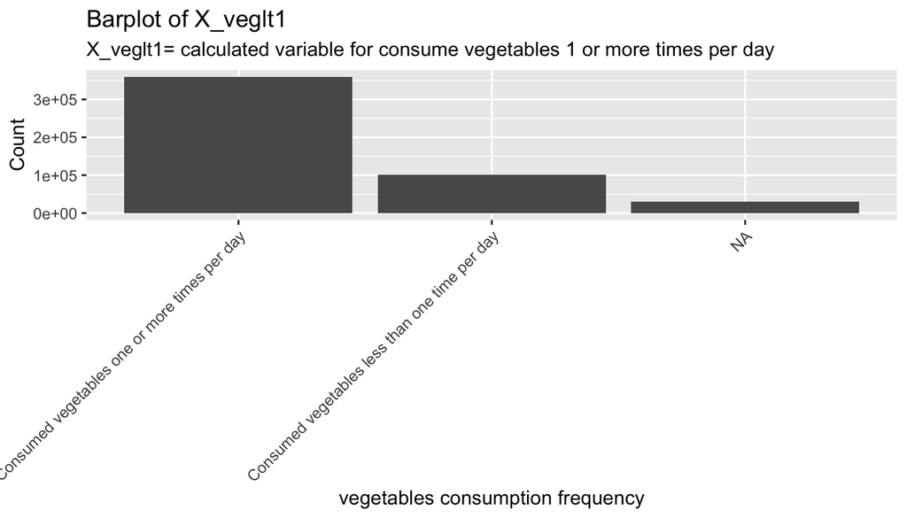

```r
ggplot(data=brfss2013_clean, aes(X_veglt1))+geom_bar() +theme(axis.text.x = element_text(angle=45, hjust=1) )+ labs(x = "vegetables consumption frequency", y = "Count", title="Barplot of X_veglt1", subtitle = "X_veglt1= calculated variable for consume vegetables 1 or more times per day")
```

We visualize the variable X_vegesum, calculated variable for total vegetables consumed per day.

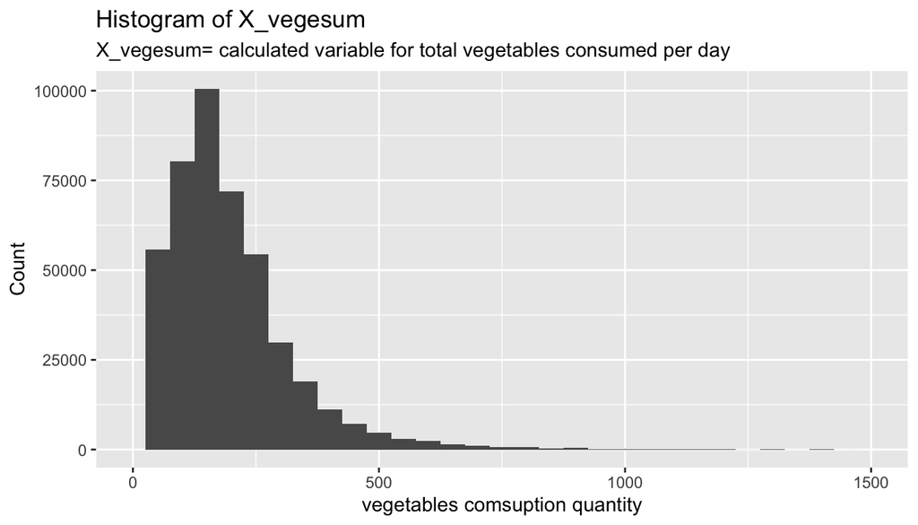

```r
ggplot(data=brfss2013_clean, aes(x=X_vegesum)) + geom_histogram(binwidth = 50) + xlim(0,1500) + labs(x = "vegetables comsuption quantity", y = "Count", title="Histogram of X_vegesum", subtitle = "X_vegesum= calculated variable for total vegetables consumed per day")
```

The distribution is unimodal, right-skewed with outliers on the right side. On the left side, the natural limit of the distribution is 0, corresponding to no vegetables consumption.

Let’s describe the variable with a boxplot.

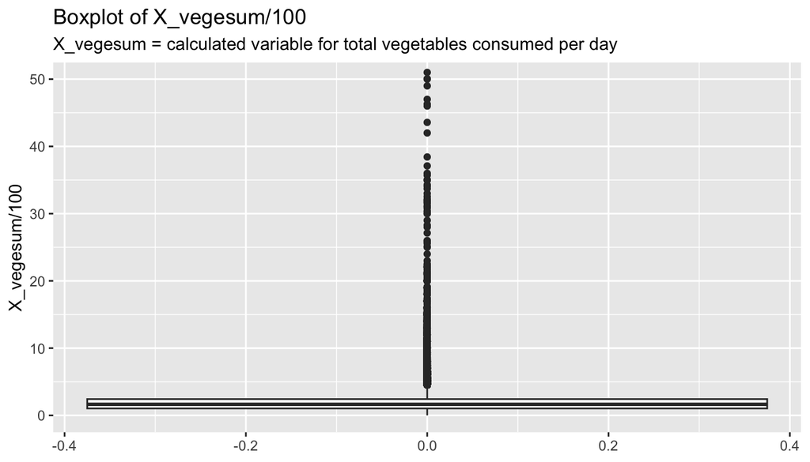

```r
ggplot(data=brfss2013_clean, aes(y=X_vegesum/100)) + geom_boxplot() +coord_cartesian(ylim = c(0,50))+ labs(title="Boxplot of X_vegesum/100", subtitle = "X_vegesum = calculated variable for total vegetables consumed per day")
```

We notice a large amount of outliers, with high values potentially not plausible.

```r
summary(brfss2013_clean$X_vegesum/100)
```

```
##    Min. 1st Qu.  Median    Mean 3rd Qu.    Max.     NAs
##    0.00    1.04    1.65    1.90    2.43  198.27   30165
```

```r
quantile(brfss2013_clean$X_vegesum/100, 0.99, na.rm = TRUE)
```

```
##  99%
## 6.57
```

Less than 1% of the data are above 657 (or 6.57 times vegetables a day). The maximal value of 198 seems implausible. For this reason we will limit the variable to the 99th percentile in the charts.

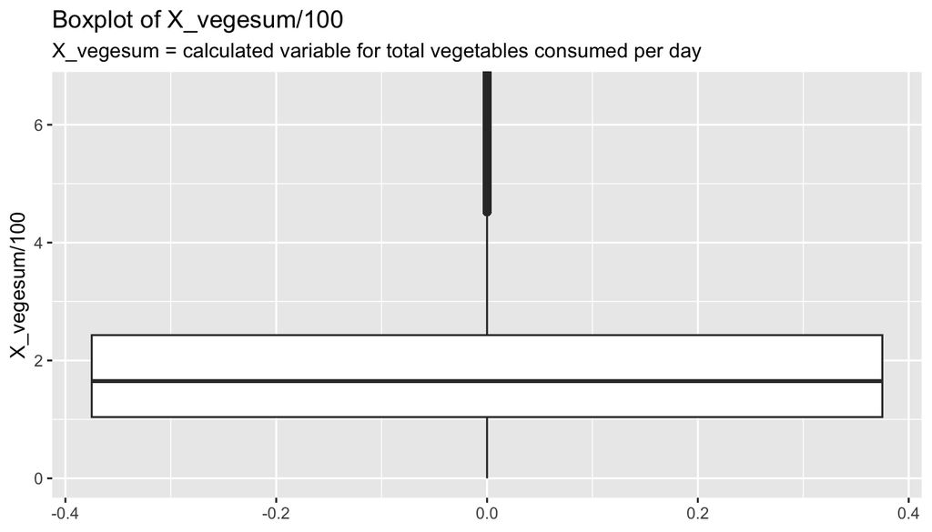

```r
ggplot(data=brfss2013_clean , aes(y=X_vegesum /100)) + geom_boxplot() +coord_cartesian(ylim = c(0, 6.57))+ labs(title="Boxplot of X_vegesum/100", subtitle = "X_vegesum = calculated variable for total vegetables consumed per day")
```

We now explore the variable PA1MIN_ , calculated variable for minutes of total physical activity per week.

```r
summary(brfss2013_clean$pa1min_)
```

```
##    Min. 1st Qu.  Median    Mean 3rd Qu.    Max.     NAs
##     0.0   109.0   240.0   440.1   495.0 81238.0  167961
```

```r
quantile(brfss2013_clean$pa1min_, 0.99, na.rm = TRUE)
```

```
##  99%
## 3360
```

Less than 1% of the data are above 3360 minutes of weekly activity.

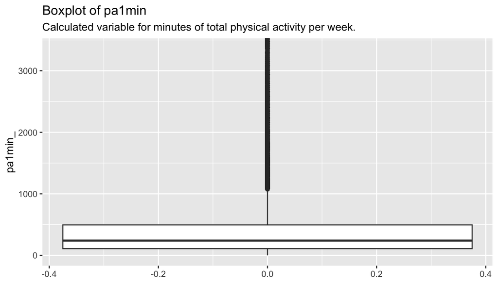

```r
ggplot(data=brfss2013_clean, aes(y=pa1min_)) + geom_boxplot() + coord_cartesian(ylim = c(0,3360)) + labs(title= "Boxplot of pa1min", subtitle= "Calculated variable for minutes of total physical activity per week. ")
```

We would like to know if the consumption of vegetables and the physical activity are correlated. We choose the Spearman correlation model, which correlates ranks instead and may adapt better to data with outliers.

```r
cor(brfss2013_clean$pa1min_, brfss2013_clean$X_vegesum, use = "complete.obs", method = "spearman")
```

```
## [1] 0.1331163
```

The Spearman’s rank correlation coefficient “rho” indicates a weak positive correlation between pa1min_ and X_vegesum.

We further analyze whether there is a association between vegetables consumption and physical activity using the category variable X_VEGLT1, calculated variable for consuming vegetables 1 or more times per day.

```r
summary(brfss2013_clean$X_veglt1)
```

```
##  Consumed vegetables one or more times per day
##                                         359834
## Consumed vegetables less than one time per day
##                                         101777
##                                            NAs
##                                          30164
```

We visualise the boxplot of physical activity grouped by category of vegetables consumption X_veglt1, Calculated variable for consuming vegetables 1 or more times per day.

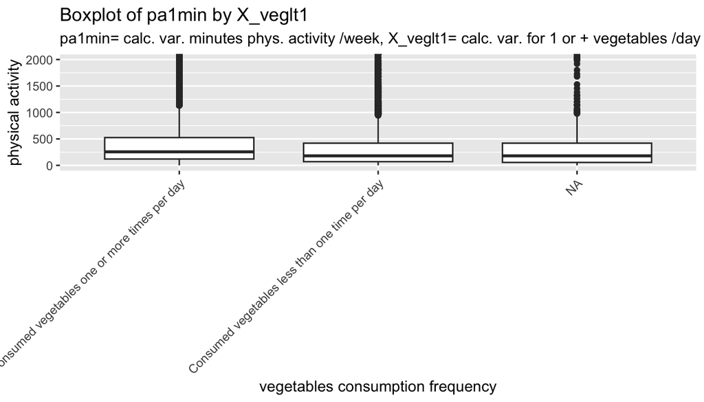

```r
ggplot(data=brfss2013_clean, aes(x=X_veglt1, y=pa1min_)) + geom_boxplot() +theme(axis.text.x = element_text(angle = 45, hjust = 1))+ coord_cartesian(ylim = c(0,2000)) + labs(x="vegetables consumption frequency", y="physical activity", title= "Boxplot of pa1min by X_veglt1", subtitle= "pa1min= calc. var. minutes phys. activity /week, X_veglt1= calc. var. for 1 or + vegetables /day")
```

On the graph we see that the median physical activity of the respondents consuming vegetables one or more times per day is higher than that of respondents consuming vegetables less than one time per day.

```r
brfss2013_clean %>%
  filter(!is.na(X_veglt1)) %>%
  group_by(X_veglt1) %>%
  summarise(median_activity= median(pa1min_,na.rm = TRUE), mean_activity=mean(pa1min_, na.rm=TRUE))
```

```
## # A tibble: 2 × 3
##   X_veglt1                                       median_activity mean_activity
##   <fct>                                                    <dbl>         <dbl>
## 1 Consumed vegetables one or more times per day              256          456.
## 2 Consumed vegetables less than one time per day             180          366.
```

This observation is confirmed calculating median and mean metrics for both categories. Median physical activity for category “Consumed vegetables one or more times per day” is 256 minutes / week, whereas median for category “Consumed vegetables less than one time per day” is 180 minutes/ week.

## Conclusion on Research question 3

**A higher consumption of vegetables is weakly associated with a higher physical activity.**

#### Author

**Marion HOULIERE**